# act_report

## Report: act_report

```python
# import dependencies
from PIL import Image
import requests
import seaborn as sns
import matplotlib.pyplot as plt
import pandas as pd
import numpy as np
```

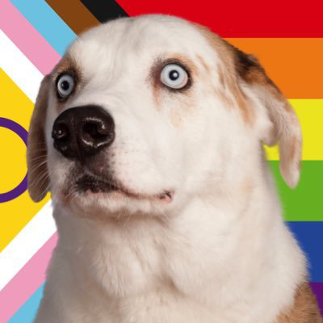

```python
# Bring in this cute #weratedogs poster
url = "https://pbs.twimg.com/profile_images/1532010275708223491/-SBRbLoH_400x400.jpg"
weratedogs = Image.open(requests.get(url, stream=True).raw)
weratedogs
```

```python
# Bring in the twitter_archive_master dataset
df= pd.read_csv("twitter_archive_master.csv")
df
```

|  | tweet_id | timestamp | text | expanded_urls | rating_numerator | rating_denominator | name | dog_stage | image_url | image_number | ... | prediction_1_confidence | prediction_1_is_dog | prediction_2 | prediction_2_confidence | prediction_2_is_dog | prediction_3 | prediction_3_confidence | prediction_3_is_dog | retweet_count | favourite_count |
| --- | --- | --- | --- | --- | --- | --- | --- | --- | --- | --- | --- | --- | --- | --- | --- | --- | --- | --- | --- | --- | --- |
| 0 | 891689557279858688 | 2017-07-30 15:58:51+00:00 | This is Darla. She commenced a snooze mid meal... | https://twitter.com/dog_rates/status/891689557... | 13 | 10 | Darla | NaN | https://pbs.twimg.com/media/DF_q7IAWsAEuuN8.jpg | 1 | ... | 0.170278 | False | labrador_retriever | 0.168086 | True | spatula | 0.040836 | False | 7229 | 36959 |
| 1 | 891327558926688256 | 2017-07-29 16:00:24+00:00 | This is Franklin. He would like you to stop ca... | https://twitter.com/dog_rates/status/891327558... | 12 | 10 | Franklin | NaN | https://pbs.twimg.com/media/DF6hr6BUMAAzZgT.jpg | 2 | ... | 0.555712 | True | english_springer | 0.225770 | True | german_short-haired_pointer | 0.175219 | True | 7768 | 35332 |
| 2 | 891087950875897856 | 2017-07-29 00:08:17+00:00 | Here we have a majestic great white breaching ... | https://twitter.com/dog_rates/status/891087950... | 13 | 10 | None | NaN | https://pbs.twimg.com/media/DF3HwyEWsAABqE6.jpg | 1 | ... | 0.425595 | True | irish_terrier | 0.116317 | True | indian_elephant | 0.076902 | False | 2602 | 17820 |
| 3 | 890971913173991426 | 2017-07-28 16:27:12+00:00 | Meet Jax. He enjoys ice cream so much he gets ... | https://gofundme.com/ydvmve-surgery-for-jax,ht... | 13 | 10 | Jax | NaN | https://pbs.twimg.com/media/DF1eOmZXUAALUcq.jpg | 1 | ... | 0.341703 | True | border_collie | 0.199287 | True | ice_lolly | 0.193548 | False | 1667 | 10372 |
| 4 | 890729181411237888 | 2017-07-28 00:22:40+00:00 | When you watch your owner call another dog a g... | https://twitter.com/dog_rates/status/890729181... | 13 | 10 | None | NaN | https://pbs.twimg.com/media/DFyBahAVwAAhUTd.jpg | 2 | ... | 0.566142 | True | eskimo_dog | 0.178406 | True | pembroke | 0.076507 | True | 15766 | 56898 |
| ... | ... | ... | ... | ... | ... | ... | ... | ... | ... | ... | ... | ... | ... | ... | ... | ... | ... | ... | ... | ... | ... |
| 2049 | 666049248165822465 | 2015-11-16 00:24:50+00:00 | Here we have a 1949 1st generation vulpix. Enj... | https://twitter.com/dog_rates/status/666049248... | 5 | 10 | None | NaN | https://pbs.twimg.com/media/CT5IQmsXIAAKY4A.jpg | 1 | ... | 0.560311 | True | rottweiler | 0.243682 | True | doberman | 0.154629 | True | 37 | 89 |
| 2050 | 666044226329800704 | 2015-11-16 00:04:52+00:00 | This is a purebred Piers Morgan. Loves to Netf... | https://twitter.com/dog_rates/status/666044226... | 6 | 10 | a | NaN | https://pbs.twimg.com/media/CT5Dr8HUEAA-lEu.jpg | 1 | ... | 0.408143 | True | redbone | 0.360687 | True | miniature_pinscher | 0.222752 | True | 115 | 247 |
| 2051 | 666033412701032449 | 2015-11-15 23:21:54+00:00 | Here is a very happy pup. Big fan of well-main... | https://twitter.com/dog_rates/status/666033412... | 9 | 10 | a | NaN | https://pbs.twimg.com/media/CT4521TWwAEvMyu.jpg | 1 | ... | 0.596461 | True | malinois | 0.138584 | True | bloodhound | 0.116197 | True | 36 | 100 |
| 2052 | 666029285002620928 | 2015-11-15 23:05:30+00:00 | This is a western brown Mitsubishi terrier. Up... | https://twitter.com/dog_rates/status/666029285... | 7 | 10 | a | NaN | https://pbs.twimg.com/media/CT42GRgUYAA5iDo.jpg | 1 | ... | 0.506826 | True | miniature_pinscher | 0.074192 | True | rhodesian_ridgeback | 0.072010 | True | 39 | 112 |
| 2053 | 666020888022790149 | 2015-11-15 22:32:08+00:00 | Here we have a Japanese Irish Setter. Lost eye... | https://twitter.com/dog_rates/status/666020888... | 8 | 10 | None | NaN | https://pbs.twimg.com/media/CT4udn0WwAA0aMy.jpg | 1 | ... | 0.465074 | True | collie | 0.156665 | True | shetland_sheepdog | 0.061428 | True | 423 | 2294 |

2054 rows × 21 columns

### Analysing the Data

After wrangling, the data was stored to a CSV file named `"twitter_archive_master.csv”`.

For Analysis, the clean master CSV file was assigned to the variable name “df”. From the clean dataframe, there were a lot of insights and possibilities to explore. I was curious to know more about the *names of the dogs rated*, *their dog stages* and *the dog’s retweets and favourites count*.

To make sense of all I wanted to explore, I created a list of questions I would like to answer. See below:

> Questions to answer
> 1. What are the most common dog names in the rated dogs?
> 2. Which of the dog stages has the highest favourites?
> 3. Which of the dog stages has the highest retweets?
> 4. What are the top 20 best-rated dog breeds in the #weratedogs archive?

### Insights

#### *Most common dog names*

To get the most common dog names, I used the value_counts method which returns the counts of unique values of the column.

The result by default is in descending order so that the first element is the most frequently-occurring element.

Based on the findings the most common dog names in the #weratedogs archive are `Charlie`, `Oliver`, `Tucker`, `Penny`, `Cooper`, `Lucy`, `Bo`, `Winston`, `Lola` and `Sadie`.

```python
# Using a value_counts method to group dog names by count
pd.DataFrame(df[['name']].value_counts(), columns= ['count']).reset_index().head(20)
```

|  | name | count |
| --- | --- | --- |
| 0 | None | 571 |
| 1 | a | 55 |
| 2 | Charlie | 10 |
| 3 | Oliver | 10 |
| 4 | Tucker | 10 |
| 5 | Penny | 10 |
| 6 | Cooper | 10 |
| 7 | Lucy | 9 |
| 8 | Bo | 8 |
| 9 | Winston | 8 |
| 10 | Lola | 8 |
| 11 | Sadie | 8 |
| 12 | an | 7 |
| 13 | Toby | 7 |
| 14 | the | 7 |
| 15 | Daisy | 7 |
| 16 | Milo | 6 |
| 17 | Rusty | 6 |
| 18 | Stanley | 6 |
| 19 | Jax | 6 |

#### *Dog stages with the highest favourites*

To get the dog stages with the highest favourites, I subsetted the data to show the dog stages using groupby operation and summed the data by favourite_count.

To show the descending order I sorted using the sort_values method.

Based on this, I found that the dog stage with the highest favourites is the `pupper` with an overall score of `1260481.0`.

```python
#Use groupby to group dog stages, summed by favourite_count and sorted using sort_values
df.groupby(['dog_stage']).sum()[['favourite_count']].reset_index().sort_values('favourite_count', ascending=False)
```

|  | dog_stage | favourite_count |
| --- | --- | --- |
| 5 | pupper | 1260481.0 |
| 0 | doggo | 1092047.0 |
| 6 | puppo | 430858.0 |
| 2 | doggopupper | 108409.0 |
| 4 | floofer | 78631.0 |
| 3 | doggopuppo | 41935.0 |
| 1 | doggofloofer | 14848.0 |

#### *Dog stages with the highest retweets*

To get the dog stages with the highest retweets, I subsetted the data to show the dog stages using groupby operation and summed the data by retweet_count. To show the descending order I sorted using the sort_values method. Based on this, I found that the dog stage with the highest retweets is the `doggo` with an overall score of `427619.0`.

```python
#Use groupby to group dog stages, summed by retweet_count and sorted using sort_values
df.groupby(['dog_stage']).sum()[['retweet_count']].reset_index().sort_values('retweet_count', ascending=False)
```

|  | dog_stage | retweet_count |
| --- | --- | --- |
| 0 | doggo | 427619.0 |
| 5 | pupper | 418618.0 |
| 6 | puppo | 121648.0 |
| 2 | doggopupper | 49497.0 |
| 4 | floofer | 27924.0 |
| 3 | doggopuppo | 16147.0 |
| 1 | doggofloofer | 2797.0 |

#### *The top 20 best-rated dog breeds*

To find the best-rated dog breeds, I also used the groupby to group dog breed names, using the mean of the rating(rating_numerator/rating_denominator) and sorted in descending order using the sort_values method.

From the analysis, I found that the top dog breed is `clumber`, followed by `soft-coated_wheaten_terrier`, `west_highland_white_terrier`, `great_pyrenees`, `borzoi`, `labrador_retriever`, `siberian_husky`, `golden_retriever`, `pomeranian`, `saluki` and `tibetan_mastiff`.

```python
# Get rating by dividing the rating numerator by the rating denominator
#Use groupby to group dog breed names, using the mean of rating and sorted using sort_values
df['rating']= df['rating_numerator']/df['rating_denominator']
df[df['prediction_1_is_dog']== True].groupby(['prediction_1']).mean()[['rating']].reset_index().sort_values('rating', ascending=False).head(20)
```

|  | prediction_1 | rating |
| --- | --- | --- |
| 28 | clumber | 2.700000 |
| 94 | soft-coated_wheaten_terrier | 2.545455 |
| 107 | west_highland_white_terrier | 1.564286 |
| 47 | great_pyrenees | 1.492857 |
| 16 | borzoi | 1.444444 |
| 60 | labrador_retriever | 1.386458 |
| 92 | siberian_husky | 1.325000 |
| 44 | golden_retriever | 1.310000 |
| 79 | pomeranian | 1.286842 |
| 85 | saluki | 1.250000 |
| 99 | tibetan_mastiff | 1.240000 |
| 20 | briard | 1.233333 |
| 15 | border_terrier | 1.214286 |
| 59 | kuvasz | 1.206250 |
| 93 | silky_terrier | 1.200000 |
| 97 | standard_schnauzer | 1.200000 |
| 43 | giant_schnauzer | 1.200000 |
| 51 | irish_setter | 1.183333 |
| 38 | eskimo_dog | 1.177778 |
| 45 | gordon_setter | 1.175000 |

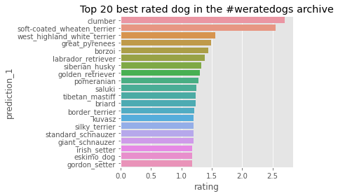

```python
# top 20 best rated dog breeds
viz_df= df[df['prediction_1_is_dog']== True].groupby(['prediction_1']).mean()[['rating']].reset_index().sort_values('rating', ascending=False).head(20)
plt.style.use('ggplot')
fig, axes= plt.subplots()
sns.barplot(y= 'prediction_1', x= 'rating', data= viz_df)
plt.title('Top 20 best rated dog in the #weratedogs archive')
plt.tight_layout()
```